# COMPSCIX 415.2 Homework 6

Rachel Hollowgrass

3/13/2018

```r
library(mosaicData)
library(tidyverse)
```

### Exercise 1

Load the `Whickham` dataset (`data(Whickham)`). You will need to load the mosaicData package first, but I also included the data as an rds file on Canvas if you would rather download it there and load it with `readRDS()`.

Look at the help file on this dataset to learn a bit about it.

**1.** What variables are in this data set?

The variables in this data set are:

- `outcome`
- `smoker`
- `age`

**2.** How many observations are there and what does each represent?

There are 1,314 observations. Each observation represents the age and tobacco smoking status of voting-age women from Whickham, UK in 1972-1974. The `outcome` represents a follow-up survey conducted 20 years later, indicating whether or not the woman was alive or dead.

**3.** Create a table (use the R code below as a guide) and a visualization of the relationship between smoking status and outcome, ignoring age. What do you see? Does it make sense?

I associate smoking with death, so I was surprised to see that the proportion of survivors (“alive”) was about evenly split between smokers and non-smokers. I was even more surpised that more non-smokers were dead than smokers. I assume that factoring in age and years of smoking would shed some light on this.

```r
whickham2 <- Whickham %>% count(smoker, outcome)
whickham2
```

```
## # A tibble: 4 x 3
##   smoker outcome     n
##   <fct>  <fct>   <int>
## 1 No     Alive     502
## 2 No     Dead      230
## 3 Yes    Alive     443
## 4 Yes    Dead      139
```

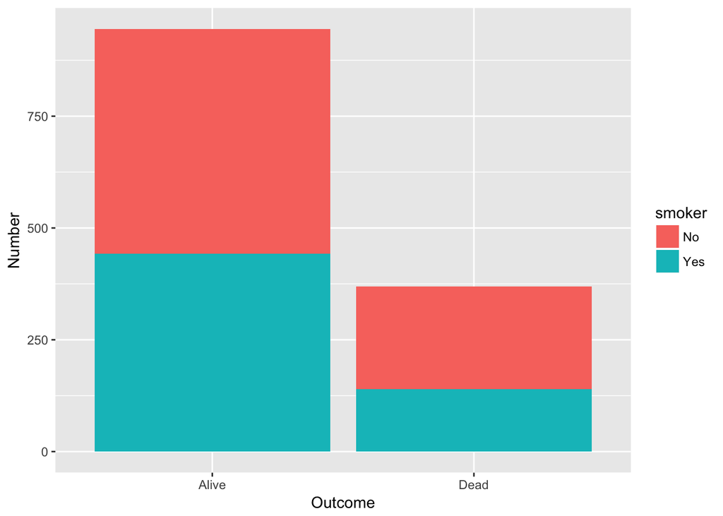

```r
ggplot(whickham2) +
  geom_col(aes(x = outcome, y = n, fill = smoker), position = "stack") +
  labs(x = "Outcome", y = "Number")
```

**4.** Recode the `age` variable into an ordered factor with three categories: age <= 44, age > 44 & age <= 64, and age > 64. Now, recreate visualization from above, but facet on your new age factor. What do you see? Does it make sense?

```r
whickham3 <- Whickham %>% mutate(age_fct =
  factor(case_when(age <= 44 ~ 'Under 45',
                  age > 44 & age <= 64 ~ '45 to 64',
                  age > 64 ~ '65 and over'),
             levels = c('Under 45', '45 to 64', '65 and over')))
whickham4 <- whickham3 %>% count(smoker, outcome, age_fct)
whickham4
```

```
## # A tibble: 12 x 4
##    smoker outcome age_fct         n
##    <fct>  <fct>   <fct>       <int>
##  1 No     Alive   Under 45      327
##  2 No     Alive   45 to 64      147
##  3 No     Alive   65 and over    28
##  4 No     Dead    Under 45       12
##  5 No     Dead    45 to 64       53
##  6 No     Dead    65 and over   165
##  7 Yes    Alive   Under 45      270
##  8 Yes    Alive   45 to 64      167
##  9 Yes    Alive   65 and over     6
## 10 Yes    Dead    Under 45       15
## 11 Yes    Dead    45 to 64       80
## 12 Yes    Dead    65 and over    44
```

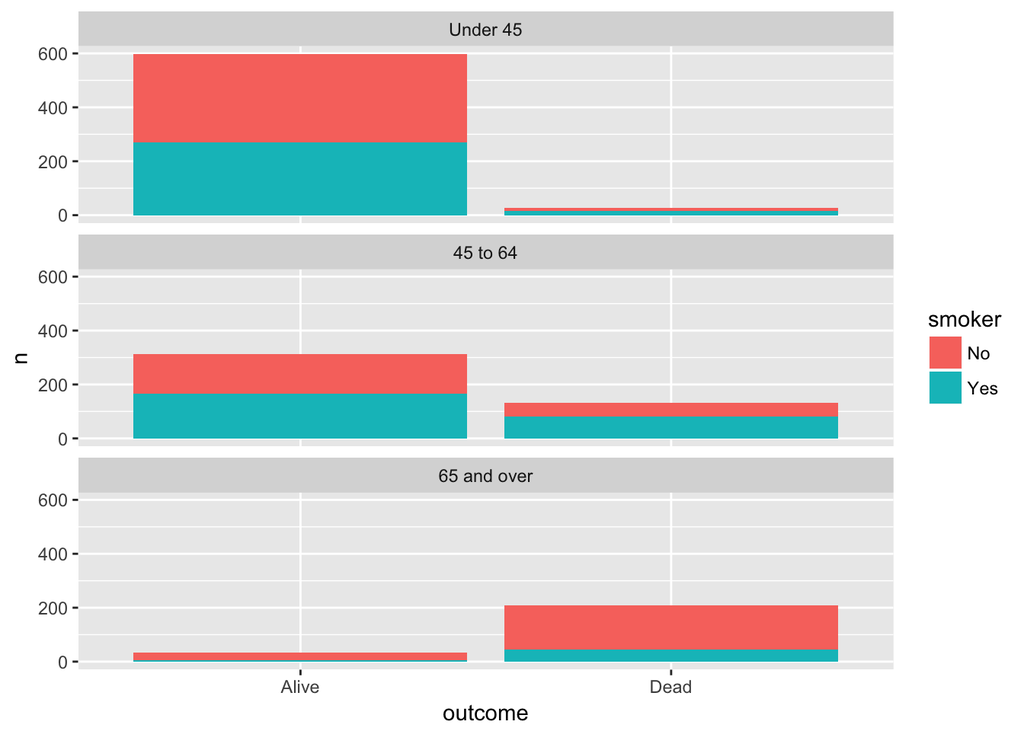

```r
ggplot(whickham4) +
  geom_col(aes(x = outcome, y = n, fill = smoker), position = "stack") +
  facet_wrap(~ age_fct, nrow = 8)
```

### Exercise 2

The Central Limit Theorem states that the sampling distribution of sample means is approximately Normal, regardless of the distribution of your population. For this exercise our population distribution will be a Gamma(1,2) distribution, and we’ll show that the sampling distribution of the mean is in fact normally distributed.

**1.** Generate a random sample of size n = 10000 from a gamma(1,2) distribution and plot a histogram or density curve. Use the code below to help you get your sample.

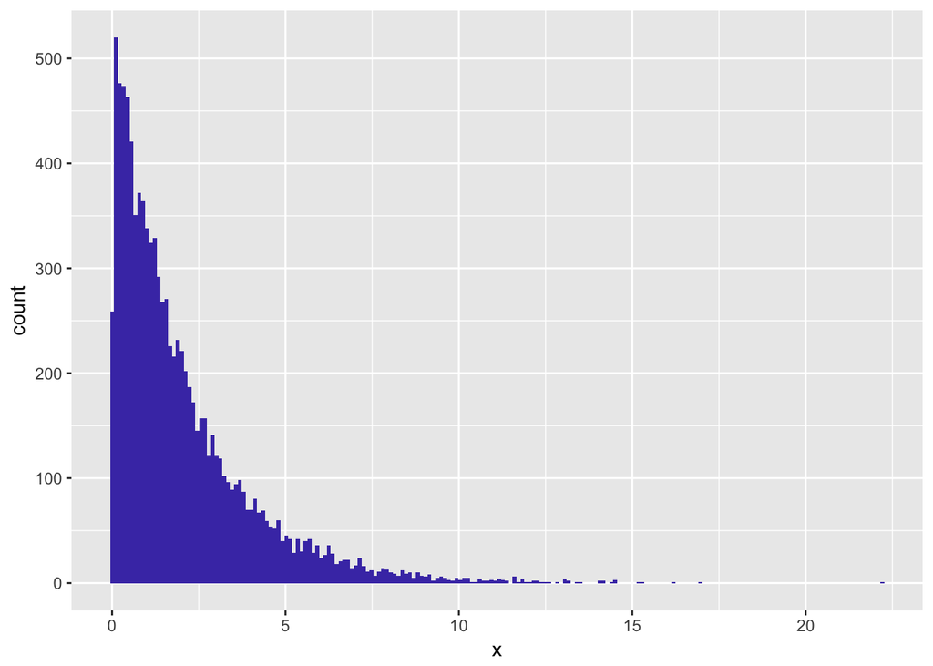

```r
n <- 10000
# look at ?rgamma to read about this function
gamma_samp <- tibble(x = rgamma(n, shape = 1, scale = 2))
gamma_samp %>% ggplot(aes(x)) + geom_histogram(bins = 200, fill = "#493BB4")
```

**2.** What is the mean and standard deviation of your sample? They should both be close to 2 because for a gamma distribution:

- mean = shape x scale
- variance = shape x scale^2

The mean and standard deviation of the sample vary each time the sample is drawn. Both have been approximately 2.

```r
gamma_samp <- tibble(x = rgamma(10000, shape = 1, scale = 2))
mean_samp <- gamma_samp %>% .[['x']] %>% mean()
sd_samp <- gamma_samp %>% .[['x']] %>% sd()
mean_samp
```

```
## [1] 1.999796
```

```r
sd_samp
```

```
## [1] 1.987389
```

**3.** Pretend the distribution of our **population** of data looks like the plot above. Now take a sample of size n = 30 from a Gamma(1,2) distribution, plot the histogram or density curve, and calculate the mean and standard deviation.

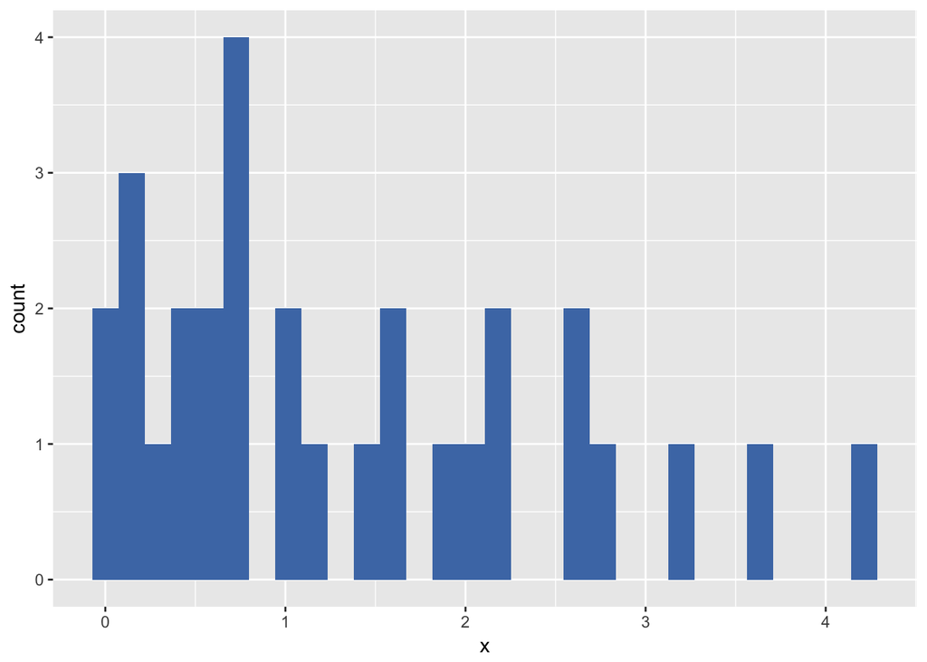

```r
population <- tibble(x = rgamma(10000, shape = 1, scale = 2))
sample_size = 30
population_sample <- sample_n(population, sample_size)
# population_sample
ggplot(population_sample) +
  geom_histogram(aes(x), fill = "#4C79B4")
```

```r
mean_pop_samp <- population_sample %>% .[['x']] %>% mean()
sd_pop_samp <- population_sample %>% .[['x']] %>% sd()
mean_pop_samp
```

```
## [1] 1.356561
```

```r
sd_pop_samp
```

```
## [1] 1.152768
```

**4.** Take a sample of size n = 30, again from the Gamma(1,2) distribution, calculate the mean, and assign it to a vector named mean_samp. Repeat this 10000 times!!!! The code below might help.

**5.** Make a histogram of your collection of means from above (`mean_samp`).

**6.** Calculate the mean and standard deviation of all of your sample means.

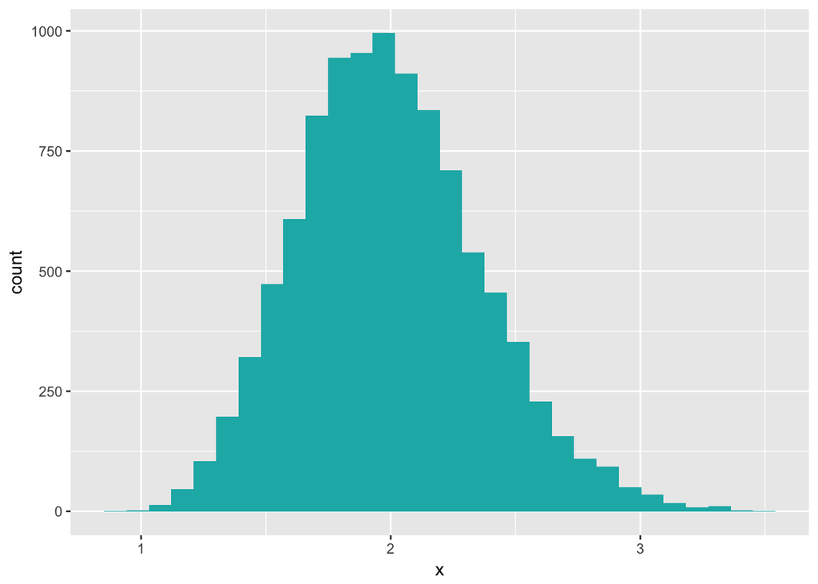

```r
# create a vector with 10000 NAs
mean_samp <- rep(NA, 10000)

# start a loop
for(i in 1:10000) {
  g_samp <- rgamma(30, shape = 1, scale = 2)
  mean_samp[i] <- mean(g_samp)
}
# Convert vector to a tibble
mean_samp <- tibble(mean_samp)
# I could not find a way for ggplot to work with this without a variable (column) name.
names(mean_samp)[1]<-"x"
mean_samp %>% ggplot(aes(x)) + geom_histogram(fill = "#18B4B4")
```

```r
mean_samp_mean <- mean_samp %>% .[['x']] %>% mean()
mean_samp_sd <- mean_samp %>% .[['x']] %>% sd()
mean_samp_mean
```

```
## [1] 1.997115
```

```r
mean_samp_sd
```

```
## [1] 0.3670043
```

**7.** Did anything surprise you about your answers to #6?

The mean was around 2, as expected. But the standard deviation has ranged between .35 and .38. I expected it to be around 2.

Repeat #4-#6, but now with a sample of size n = 300 instead. Do your results match up well with the theorem?

Yes, the results match up with the theorem.

**Expected values:**

- mean = 2.0
- sd = 0.1154701

**One result:**

- mean = 1.998485
- sd = 0.1144379

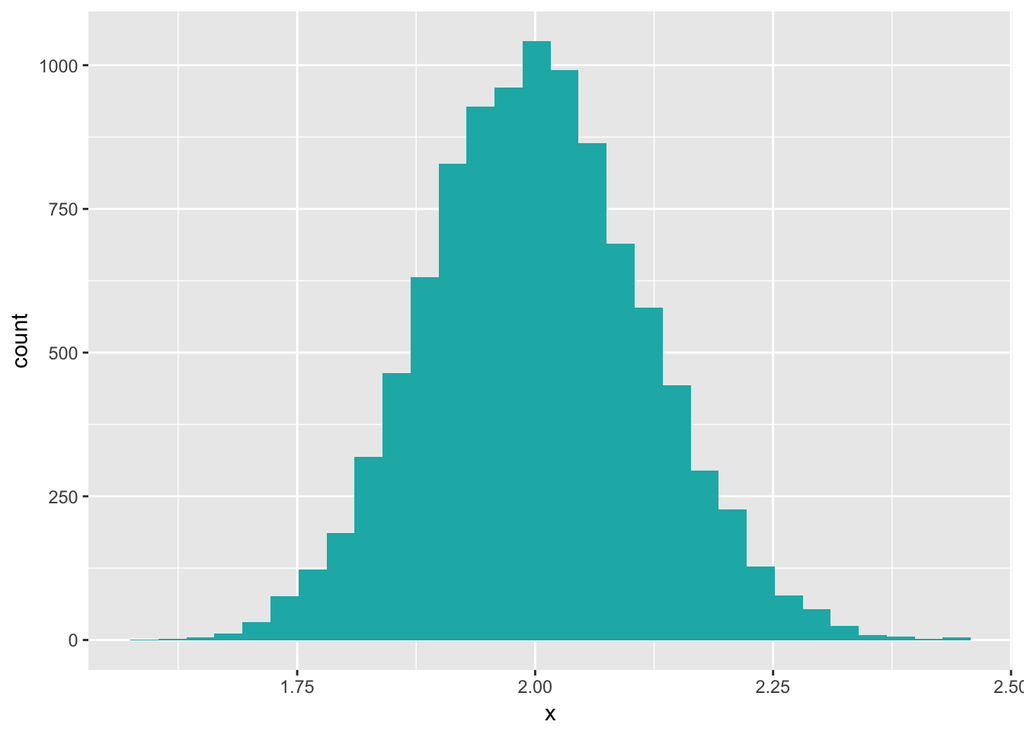

```r
# create a vector with 10000 NAs
mean_300_samp <- rep(NA, 10000)

# start a loop
for(i in 1:10000) {
  g_300_samp <- rgamma(300, shape = 1, scale = 2)
  mean_300_samp[i] <- mean(g_300_samp)
}
# Convert vector to a tibble
mean_300_samp <- tibble(mean_300_samp)
names(mean_300_samp)[1]<-"x"
mean_300_samp %>% ggplot(aes(x)) + geom_histogram(fill = "#18B4B4")
```

```r
mean_300_mean <- mean_300_samp %>% .[['x']] %>% mean()
mean_300_sd <- mean_300_samp %>% .[['x']] %>% sd()
mean_300_mean
```

```
## [1] 2.001416
```

```r
mean_300_sd
```

```
## [1] 0.1149789
```